# Régression Multiple - Sélection de variables

Paul Bastide

2025-03-12

# What we know

## Exact tests

- **t-test**: is *one* individual coefficient $k$ zero ?
  $$\begin{aligned}
  \mathcal{H}_0&: \beta_k = 0 \\
  \mathcal{H}_1&: \beta_k \neq 0
  \end{aligned}
  \quad;\quad
  T_k
  = \frac{\hat{\beta}_k}{\sqrt{\hat{\sigma}^2 [(\mathbf{X}^T\mathbf{X})^{-1}]_{kk}}}
  \underset{\mathcal{H}_0}{\sim}
  \mathcal{T}_{n-p}$$
- **Nested F-test**: are extra coefficients from the *big model* zero ?
  $${\small
  \begin{aligned}
  \mathcal{H}_0&: \beta_{p_0 + 1} = \cdots = \beta_p = 0\\
  \mathcal{H}_1&: \exists~k\in \{p_0+1, \dotsc, p\} ~|~ \beta_k \neq 0
  \end{aligned}
  ;
  F = \frac{
  \|\hat{\mathbf{y}} - \hat{\mathbf{y}}_0\|^2 / (p - p_0)
  }{
  \|\mathbf{y} - \hat{\mathbf{y}}\|^2 / (n - p)
  }
  = \frac{n - p}{p - p_0}\frac{RSS_0 - RSS}{RSS}
  \underset{\mathcal{H}_0}{\sim}
  \mathcal{F}^{p - p_0}_{n - p}
  }$$

## Exact tests

- Can only test **nested models**.
- Multiple testing issue.
- How to choose relevant predictors from a large pool of predictors ?
  - Marketing
  - Genetics
- Variable Selection

## How to choose the “best” model ?

**Model**:
$$y_i = \beta_1 x_{i1} + \dotsb + \beta_p x_{ip} + \epsilon_i$$

**Problem**:  
Can we choose the “best” subset of non-zero $\beta_k$ ?

I.e. Can we find the predictors that really have an impact on $\mathbf{y}$ ?

**Idea**:  
Find a “score” to assess the quality of a given fit.

## Variable selection - $R^2$

$$R^2 = 1 - \frac{RSS}{TSS}$$

```r
## Function to get statistics for one fit
get_stats_fit <- function(fit) {
  sumfit <- summary(fit)
  res <- data.frame(R2 = sumfit$r.squared)
  return(res)
}
```

$$y_i = -1 + 3 x_{i1} - x_{i2} + \epsilon_i$$

## Variable selection - $R^2$

- True fit

```r
get_stats_fit(lm(y_sim ~ x_1 + x_2, data = data_all))
```

```
         R2
1 0.7905255
```

- Bigger fit

```r
get_stats_fit(lm(y_sim ~ x_1 + x_2 + x_junk.1, data = data_all))
```

```
       R2
1 0.79133
```

- Wrong fit

```r
get_stats_fit(lm(y_sim ~ x_1 + x_junk.1, data = data_all))
```

```
         R2
1 0.7252314
```

## Variable selection - $R^2$

```r
## Only one "junk" predictor
data_sub <- data.frame(y_sim = y_sim,
                       x_1 = x_1,
                       x_2 = x_2,
                       x_junk = x_junk_1)
## Fit all possible models
get_all_stats(data_sub)
```

```
            R2          preds
1 0.7208723311            x_1
2 0.1158793338            x_2
3 0.0005972444         x_junk
4 0.7905254867        x_1+x_2
5 0.7208974123     x_1+x_junk
6 0.1164841596     x_2+x_junk
7 0.7905418666 x_1+x_2+x_junk
```

**$R^2$ is not enough.**

## $R^2$ is always increasing

$$R^2 = 1 - \frac{RSS}{TSS}
= 1 - \frac{\|\hat{\epsilon}\|^2}{\|\mathbf{y} - \bar{y} \mathbb{1}\|^2}
= 1 - \frac{\|\mathbf{y} - \mathbf{X}\hat{\boldsymbol{\beta}}\|^2}{\|\mathbf{y} - \bar{y} \mathbb{1}\|^2}$$

$$\text{Hence:}\quad
\|\mathbf{y} - \mathbf{X}'\hat{\boldsymbol{\beta}}'\|^2 \leq \|\mathbf{y} - \mathbf{X}\hat{\boldsymbol{\beta}}\|^2$$

## Variable selection - $R_a^2$

$$R_a^2 = 1 - \frac{RSS / (n-p)}{TSS / (n-1)}$$

- **Penalize** for the number of predictors $p$.
- **Attention** $p$ includes the intercept (rank of matrix $\mathbf{X}$).

```r
## Function to get statistics
get_stats_fit <- function(fit) {
  sumfit <- summary(fit)
  res <- data.frame(R2 = sumfit$r.squared,
                    R2a = sumfit$adj.r.squared)
  return(res)
}
```

## Variable selection - $R_a^2$

```r
get_all_stats(data_sub)
```

```
            R2          R2a          preds
1 0.7208723311  0.720311834            x_1
2 0.1158793338  0.114103991            x_2
3 0.0005972444 -0.001409588         x_junk
4 0.7905254867  0.789682531        x_1+x_2
5 0.7208974123  0.719774263     x_1+x_junk
6 0.1164841596  0.112928764     x_2+x_junk
7 0.7905418666  0.789274983 x_1+x_2+x_junk
```

**$R_a^2$: adjust for the number of predictors.**

## Adjusted $R_a^2$

$$R_a^2 = 1 - \frac{RSS / (n-p)}{TSS / (n-1)}$$

- The larger the better.
- When $p$ is bigger, the fit must be really better for $R_a^2$ to raise.
- Intuitive, but not much theoretical justifications.

# Predictive Risk

## Simulation

```r
set.seed(1289)

## Predictors
n <- 50
x_1 <- runif(n, min = -2, max = 2)
x_2 <- runif(n, min = -2, max = 2)

## Model
beta_0 <- -1; beta_1 <- 3; beta_2 <- -1

## sim
eps <- rnorm(n, mean = 0, sd = 2)
y_sim <- beta_0 + beta_1 * x_1 + beta_2 * x_2 + eps
```

## Simulation - Fit

```r
## Useless predictors
p_junk <- 48
x_junk <- matrix(runif(n * p_junk, min = -2, max = 2),
                 ncol = p_junk)

## Good and Bad dataset
data_all <- data.frame(y_sim = y_sim,
                       x_1 = x_1,
                       x_2 = x_2,
                       x_junk = x_junk)

## Bad overfitting fit
fit_bad <- lm(y_sim ~ ., data = data_all)
pred_bad <- predict(fit_bad)

## Good fit
fit_good <- lm(y_sim ~ x_1 + x_2, data = data_all)
pred_good <- predict(fit_good)
```

## Simulation - Fit

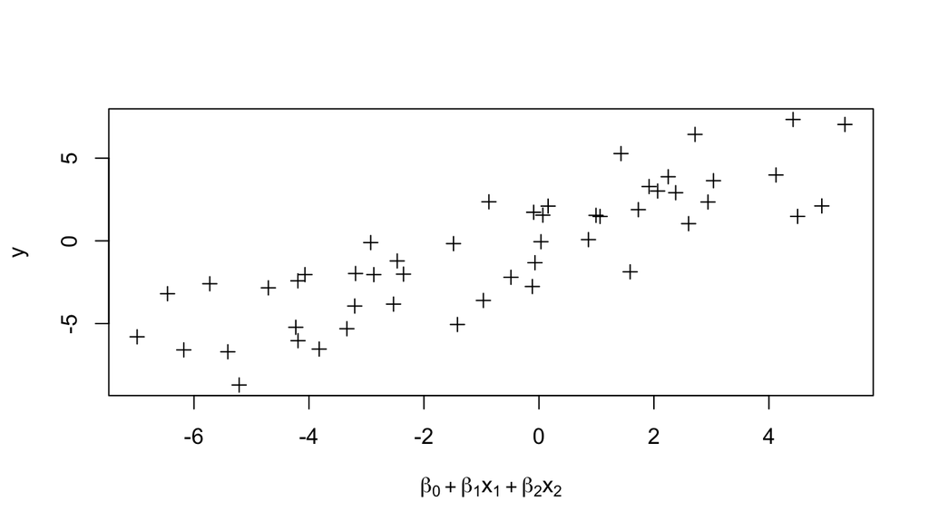

```r
mu_y <- beta_0 + beta_1 * x_1 + beta_2 * x_2
plot(mu_y, y_sim, pch = 3,
     ylab = "y", xlab = expression(beta[0] + beta[1]*x[1] + beta[2]*x[2]))
```

## Simulation - Fit

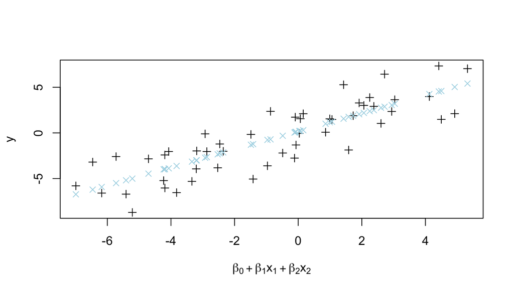

```r
mu_y <- beta_0 + beta_1 * x_1 + beta_2 * x_2
plot(mu_y, y_sim, pch = 3,
     ylab = "y", xlab = expression(beta[0] + beta[1]*x[1] + beta[2]*x[2]))
## Good prediction (small model)
points(mu_y, pred_good, col = "lightblue", pch = 4)
```

## Simulation - Fit

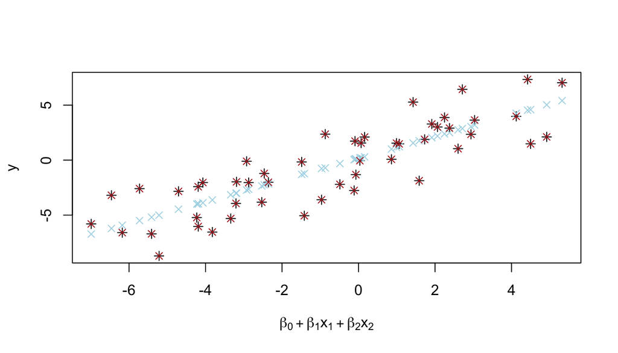

```r
mu_y <- beta_0 + beta_1 * x_1 + beta_2 * x_2
plot(mu_y, y_sim, pch = 3,
     ylab = "y", xlab = expression(beta[0] + beta[1]*x[1] + beta[2]*x[2]))
## Good prediction (small model)
points(mu_y, pred_good, col = "lightblue", pch = 4)
## Bad prediction (big model)
points(mu_y, pred_bad, col = "firebrick", pch = 4)
```

## RSS: “fitted risk”

The bad (bigger) model is closer to the observed data.

```r
## Distance between bad prediction and data (RSS)
sum((y_sim - pred_bad)^2)
```

```
[1] 3.705512e-27
```

```r
## Distance between good prediction and data (RSS)
sum((y_sim - pred_good)^2)
```

```
[1] 206.9159
```

**Overfitting**: the RSS is smaller for the bad, bigger model.

## Predictive Risk

Generate new data according to the same generative model:

```r
## New dataset from the same model
eps_new <- rnorm(n, mean = 0, sd = 2)
y_new <- beta_0 + beta_1 * x_1 + beta_2 * x_2 + eps_new
```

**Questions**:  
Are the predictions from the bad (bigger) model  
*better or worse*  
than the predictions from the good (smaller) model,  
compared to the new data ?

## Simulation - Fit

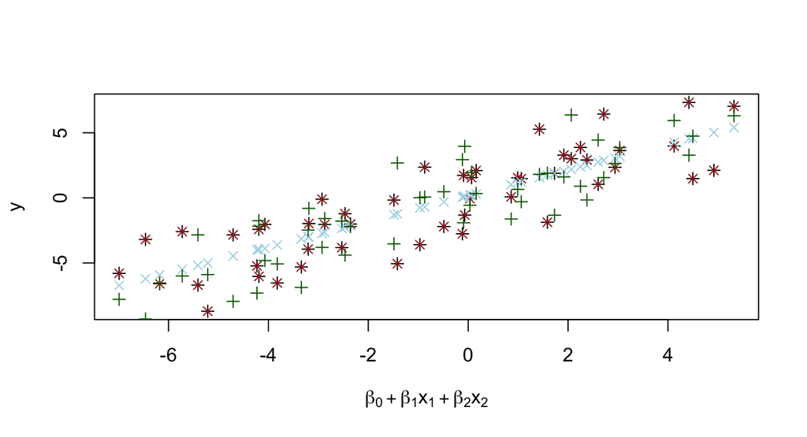

```r
plot(mu_y, y_sim, pch = 3,
     ylab = "y", xlab = expression(beta[0] + beta[1]*x[1] + beta[2]*x[2]))
## Bad prediction (big model)
points(mu_y, pred_bad, col = "firebrick", pch = 4)
## Good prediction (small model)
points(mu_y, pred_good, col = "lightblue", pch = 4)
## New points
points(mu_y, y_new, col = "darkgreen", pch = 3)
```

## Predictive Risk

Compute the risk between predictions and new data:

```r
## Distance between bad prediction and true
sum((y_new - pred_bad)^2)
```

```
[1] 535.296
```

```r
## Distance between good prediction and true
sum((y_new - pred_good)^2)
```

```
[1] 205.6555
```

The good (smaller) model behaves better on new data.

## Predictive Risk

**RSS**: $\|\mathbf{y} - \hat{\mathbf{y}}_p\|^2$ with $\hat{\mathbf{y}}_p$ learnt on $\mathbf{y}$  
$\to$ gets smaller when model gets bigger (overfit).

**Predictive Risk**: $\| \mathbf{y}' - \hat{\mathbf{y}}_p\|^2$ with $\mathbf{y}'$ same distribution as $\mathbf{y}$.  
$\to$ becomes larger if $\hat{\mathbf{y}}_p$ is overfit.

**Idea**:  
We want to select a model that has a good **predictive** risk.  
i.e. that represents the underlying model best.

**Problem**:  
In general, we don’t have means to generate $\mathbf{y}'$.  
$\to$ We use an *estimate* of the (theoretical) predictive risk.

# Theoretical Risk

## Models

**Ideal model**:
$$\mathbf{y} = \boldsymbol{\mu} + \boldsymbol{\epsilon}
\quad
\boldsymbol{\mu} \in \mathbb{R}^n
\quad
\boldsymbol{\epsilon} \sim \mathcal{N}(\mathbf{0}, \sigma^2\mathbf{I}_n).$$

$\boldsymbol{\mu}$ the “true” expectation of the observations $\mathbf{y}$.

**Full linear regression model**:
$$\mathbf{y} = \mathbf{X} \boldsymbol{\beta} + \boldsymbol{\epsilon}
\quad
rg(\mathbf{X}) = p,
\quad
\boldsymbol{\epsilon} \sim \mathcal{N}(\mathbf{0}, \sigma^2\mathbf{I}_n).$$

Assume that $\boldsymbol{\mu}$ can be approximated as $\mathbf{X} \boldsymbol{\beta}$, i.e. as an element of $\mathcal{M}(\mathbf{X})$.

## Models

**Ideal model**:
$$\mathbf{y} = \boldsymbol{\mu} + \boldsymbol{\epsilon}
\quad
\boldsymbol{\mu} \in \mathbb{R}^n
\quad
\boldsymbol{\epsilon} \sim \mathcal{N}(\mathbf{0}, \sigma^2\mathbf{I}_n).$$

**Sub-models**:
keep only predictors $\eta \subset \{1, \dotsc, p\}$
$$\mathbf{y} = \mathbf{X}_{\eta} \boldsymbol{\beta}_{\eta} + \boldsymbol{\epsilon}_{\eta}
\quad
rg(\mathbf{X}_{\eta}) = |\eta|,
\quad
\boldsymbol{\epsilon}_{\eta} \sim \mathcal{N}(\mathbf{0}, \sigma^2\mathbf{I}_n).$$

with $\mathbf{X}_{\eta}$ the sub-matrix of $\mathbf{X}$:
$$\mathbf{X}_{\eta} = (\mathbf{x}_{\eta_1} ~ \mathbf{x}_{\eta_2} \cdots \mathbf{x}_{\eta_{|\eta|}})$$

Assume that $\boldsymbol{\mu}$ can be approximated as $\mathbf{X}_{\eta} \boldsymbol{\beta}_{\eta}$, i.e. as an element of $\mathcal{M}(\mathbf{X}_{\eta})$.

## Models

**“Truth”**: $\mathbf{y} = \boldsymbol{\mu} + \boldsymbol{\epsilon}$, with $\boldsymbol{\mu} \in \mathbb{R}^n$ and $\boldsymbol{\epsilon} \sim \mathcal{N}(\mathbf{0}, \sigma^2\mathbf{I}_n)$.

**Models:**
$$\mathbf{y} = \mathbf{X}_{\eta} \boldsymbol{\beta}_{\eta} + \boldsymbol{\epsilon}_{\eta}
\quad
rg(\mathbf{X}_{\eta}) = |\eta|,
\quad
\boldsymbol{\epsilon}_{\eta} \sim \mathcal{N}(\mathbf{0}, \sigma^2\mathbf{I}_n).$$

**Estimators:**
$$\begin{aligned}
\hat{\boldsymbol{\beta}}_\eta
& = \underset{\boldsymbol{\beta} \in \mathbb{R}^{|\eta|}}{\operatorname{argmin}}
\|\mathbf{y} - \mathbf{X}_\eta\boldsymbol{\beta}_\eta \|^2
= (\mathbf{X}_\eta^{T}\mathbf{X}_\eta)^{-1}\mathbf{X}_\eta^{T}\mathbf{y}\\
\hat{\mathbf{y}}_\eta
& = \mathbf{X}_\eta\hat{\boldsymbol{\beta}}_\eta
= \mathbf{P}^{\mathbf{X}_\eta}\mathbf{y}
\end{aligned}$$

**True expectation**:
$$\begin{aligned}
\mathbf{y}_\eta
= \mathbf{P}^{\mathbf{X}_\eta}\boldsymbol{\mu}
\end{aligned}$$

## Models

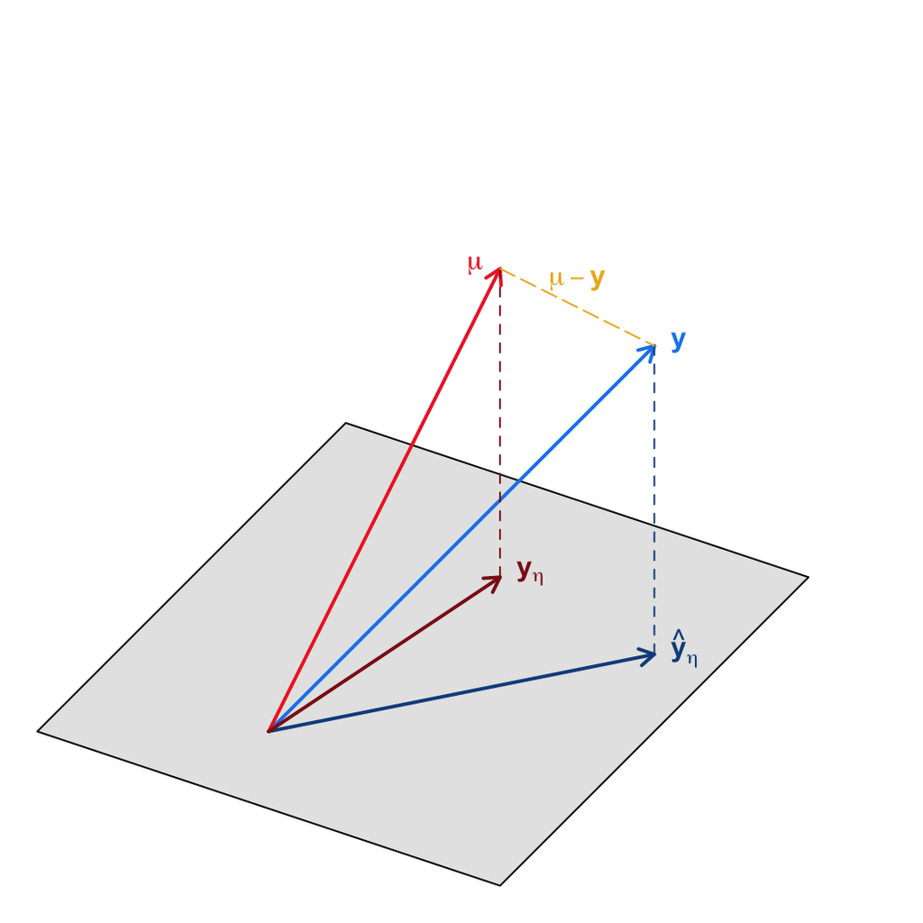

## Risk

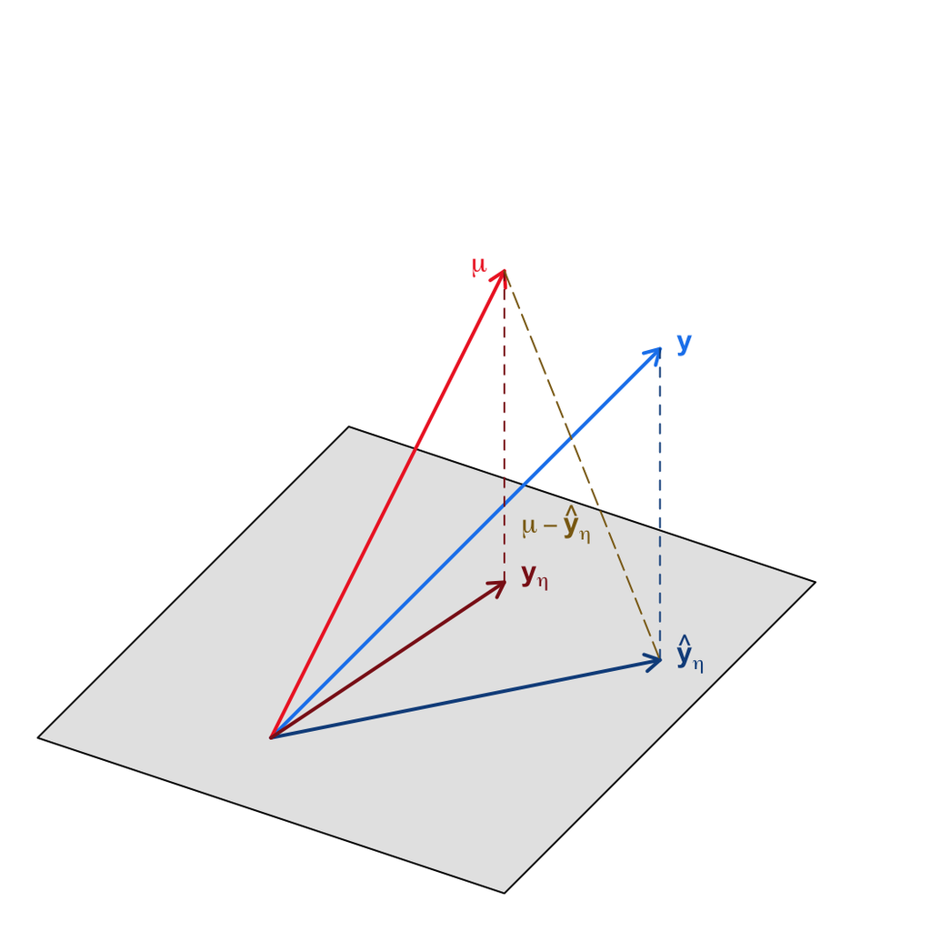

## Risk of an estimator (theoretical)

Risk of an estimator:
$$R(\hat{\mathbf{y}}_\eta)
=
\mathbb{E}\left[
\|\boldsymbol{\mu} - \hat{\mathbf{y}}_\eta \|^2
\right]$$

**Notes**:

- $\boldsymbol{\mu}$ is unknown $\to$ cannot be computed in practice.
- Expectation of the difference between the true mean and the estimated projection.
- Not subject to overfitting.

# Bias-Variance Decomposition

## Bias-Variance Decomposition

$$R(\hat{\mathbf{y}}_\eta)
=
\mathbb{E}\left[
\|\boldsymbol{\mu} - \hat{\mathbf{y}}_\eta \|^2
\right]
=
\|\boldsymbol{\mu} - \mathbf{y}_\eta \|^2 + |\eta| \sigma^2$$

- **Bias**: $\|\boldsymbol{\mu} - \mathbf{y}_\eta \|^2$
  - Difference between true and projection on the model
  - Best that we could do if we knew the truth
  - **Decreases** when model is more complex, i.e. $\eta$ gets larger.
- **Variance**: $|\eta| \sigma^2$
  - Variance of the estimation
  - **Increases** when model is more complex, i.e. $\eta$ gets larger.
- **Risk is a compromize between bias and variance.**

## Bias-Variance - No overfitting

$$R(\hat{\mathbf{y}}_\eta)
=
\mathbb{E}\left[
\|\boldsymbol{\mu} - \hat{\mathbf{y}}_\eta \|^2
\right]
=
\|\boldsymbol{\mu} - \mathbf{y}_\eta \|^2 + |\eta| \sigma^2$$

**No overfitting**:

Assume:

- $\boldsymbol{\mu} \in \mathcal{M}(\mathbf{X}_{\eta})$ so that $\mathbf{y}_{\eta} = \mathbf{P}^{\mathbf{X}_{\eta}}\boldsymbol{\mu} = \boldsymbol{\mu}$.
- $\eta \subset \eta'$ so that $\mathbf{y}_{\eta'} = \mathbf{P}^{\mathbf{X}_{\eta'}}\boldsymbol{\mu} = \boldsymbol{\mu}$.

Then:
$$\begin{aligned}
R(\hat{\mathbf{y}}_{\eta'})
& = \|\boldsymbol{\mu} - \mathbf{y}_{\eta'} \|^2 + |\eta'| \sigma^2 \\
& \geq \|\boldsymbol{\mu} - \mathbf{y}_{\eta'} \|^2 + |\eta| \sigma^2
= \|\boldsymbol{\mu} - \mathbf{y}_{\eta} \|^2 + |\eta| \sigma^2 \\
& \geq R(\hat{\mathbf{y}}_\eta)
\end{aligned}$$

## Bias-Variance - Proof - 1/2

$$R(\hat{\mathbf{y}}_\eta)
=
\mathbb{E}\left[
\|\boldsymbol{\mu} - \hat{\mathbf{y}}_\eta \|^2
\right]
=
\mathbb{E}\left[
\|\boldsymbol{\mu} - \mathbf{y}_\eta + \mathbf{y}_\eta - \hat{\mathbf{y}}_\eta \|^2
\right]$$

$$\begin{aligned}
R(\hat{\mathbf{y}}_\eta)
&=
\mathbb{E}\left[
\|\boldsymbol{\mu} - \mathbf{P}^{\mathbf{X}_{\eta}}\boldsymbol{\mu}
+ \mathbf{P}^{\mathbf{X}_{\eta}}\boldsymbol{\mu} - \mathbf{P}^{\mathbf{X}_{\eta}}\mathbf{y} \|^2
\right] \\
&=
\mathbb{E}\left[
\|(\mathbf{I}_n - \mathbf{P}^{\mathbf{X}_{\eta}})\boldsymbol{\mu}
+ \mathbf{P}^{\mathbf{X}_{\eta}}(\boldsymbol{\mu} - \mathbf{y}) \|^2
\right]\\
&=
\mathbb{E}\left[
\|\mathbf{P}^{\mathbf{X}_{\eta}^\bot}\boldsymbol{\mu}
+ \mathbf{P}^{\mathbf{X}_{\eta}}(\boldsymbol{\mu} - \mathbf{y}) \|^2
\right]
\end{aligned}$$

$$\begin{aligned}
R(\hat{\mathbf{y}}_\eta)
&=
\mathbb{E}\left[
\|\mathbf{P}^{\mathbf{X}_{\eta}^\bot}\boldsymbol{\mu} \|^2
+ \|\mathbf{P}^{\mathbf{X}_{\eta}}(\boldsymbol{\mu} - \mathbf{y}) \|^2
\right] \\
&=
\|\mathbf{P}^{\mathbf{X}_{\eta}^\bot}\boldsymbol{\mu} \|^2
+
\mathbb{E}\left[
\|\mathbf{P}^{\mathbf{X}_{\eta}}(\boldsymbol{\mu} - \mathbf{y}) \|^2
\right] \\
&=
\|\boldsymbol{\mu} - \mathbf{y}_\eta \|^2
+
\mathbb{E}\left[
\|\mathbf{P}^{\mathbf{X}_{\eta}}(\boldsymbol{\mu} - \mathbf{y}) \|^2
\right]
\end{aligned}$$

## Bias-Variance - Proof - 2/2

$$R(\hat{\mathbf{y}}_\eta)
=
\|\boldsymbol{\mu} - \mathbf{y}_\eta \|^2
+
\mathbb{E}\left[
\|\mathbf{P}^{\mathbf{X}_{\eta}}(\boldsymbol{\mu} - \mathbf{y}) \|^2
\right]$$

From Cochran’s Theorem:
$$\frac{1}{\sigma^2}\|\mathbf{P}^{\mathbf{X}_{\eta}}(\boldsymbol{\mu} - \mathbf{y}) \|^2
\sim
\chi^2_{|\eta|}$$

Hence:
$$\mathbb{E}\left[
\frac{1}{\sigma^2}\|\mathbf{P}^{\mathbf{X}_{\eta}}(\boldsymbol{\mu} - \mathbf{y}) \|^2
\right]
=
|\eta|$$

# Penalized Least Squares

## Oracle Estimator

We would like:
$$\eta_0 = \underset{\eta \subset \{1, \cdots, p\}}{\operatorname{argmin}} R(\hat{\mathbf{y}}_\eta)$$

- Minimize the risk over all possible models.
- **Problem**: $R(\hat{\mathbf{y}}_\eta)$ is theoretical $\to$ cannot be computed.
- **Idea**: Minimize an *estimator* $\hat{R}(\hat{\mathbf{y}}_\eta)$ of $R(\hat{\mathbf{y}}_\eta)$:
  $$\hat{\eta} = \underset{\eta \subset \{1, \cdots, p\}}{\operatorname{argmin}} \hat{R}(\hat{\mathbf{y}}_\eta).$$

## Expectation of the RSS

For any model $\eta$, the expectation of the RSS is:
$$\mathbb{E}[\|\mathbf{y} - \hat{\mathbf{y}}_\eta \|^2]
=
R(\hat{\mathbf{y}}_\eta) + n\sigma^2 - 2|\eta|\sigma^2$$

## Expectation of the RSS - Proof

$$\begin{aligned}
\mathbb{E}[\|\mathbf{y} - \hat{\mathbf{y}}_\eta \|^2]
&= \mathbb{E}[\|\mathbf{y} - \boldsymbol{\mu} + \boldsymbol{\mu} - \hat{\mathbf{y}}_\eta \|^2] \\
&=
\mathbb{E}[\|\mathbf{y} - \boldsymbol{\mu}\|^2
+ \|\boldsymbol{\mu} - \hat{\mathbf{y}}_\eta \|^2
+ 2 \langle \mathbf{y} - \boldsymbol{\mu}; \boldsymbol{\mu} - \hat{\mathbf{y}}_\eta \rangle]
\end{aligned}$$

$$\begin{aligned}
\mathbb{E}[\|\mathbf{y} - \hat{\mathbf{y}}_\eta \|^2]
&=
\mathbb{E}[\|\boldsymbol{\epsilon}\|^2]
+ R(\hat{\mathbf{y}}_\eta)
+ 2 \mathbb{E}[\langle \boldsymbol{\epsilon}; \boldsymbol{\mu} - \mathbf{P}^{\mathbf{X}_{\eta}}\mathbf{y} \rangle]
\qquad
\end{aligned}$$

$$\begin{aligned}
\mathbb{E}[\langle \boldsymbol{\epsilon}; \boldsymbol{\mu} - \mathbf{P}^{\mathbf{X}_{\eta}}\mathbf{y} \rangle]
&=
\mathbb{E}[\langle \boldsymbol{\epsilon}; \boldsymbol{\mu} - \mathbf{P}^{\mathbf{X}_{\eta}}(\boldsymbol{\mu} + \boldsymbol{\epsilon}) \rangle] \\
&=
\mathbb{E}[\langle \boldsymbol{\epsilon}; \boldsymbol{\mu} - \mathbf{P}^{\mathbf{X}_{\eta}}\boldsymbol{\mu}) \rangle]
- \mathbb{E}[\langle \boldsymbol{\epsilon}; \mathbf{P}^{\mathbf{X}_{\eta}}\boldsymbol{\epsilon} \rangle]
\end{aligned}$$

$$\begin{aligned}
\mathbb{E}[\langle \boldsymbol{\epsilon}; \boldsymbol{\mu} - \mathbf{P}^{\mathbf{X}_{\eta}}\mathbf{y} \rangle]
&=
0
- \mathbb{E}[\langle \mathbf{P}^{\mathbf{X}_{\eta}}\boldsymbol{\epsilon}; \mathbf{P}^{\mathbf{X}_{\eta}}\boldsymbol{\epsilon} \rangle] \qquad\qquad~~ \\
&= - \mathbb{E}[\| \mathbf{P}^{\mathbf{X}_{\eta}}\boldsymbol{\epsilon}\|^2] \\
&= - |\eta| \sigma^2
\end{aligned}$$

$$\begin{aligned}
\mathbb{E}[\|\mathbf{y} - \hat{\mathbf{y}}_\eta \|^2]
&=
n \sigma^2
+ R(\hat{\mathbf{y}}_\eta)
- 2 |\eta| \sigma^2
\qquad\qquad\qquad\qquad
\end{aligned}$$

## Mallow’s $C_p$

We have:
$$\mathbb{E}[\|\mathbf{y} - \hat{\mathbf{y}}_\eta \|^2]
=
R(\hat{\mathbf{y}}_\eta) + n\sigma^2 - 2|\eta|\sigma^2$$

Mallow’s $C_p$:
$$C_p(\hat{\mathbf{y}}_\eta) = \frac{1}{n} \left( \|\mathbf{y} - \hat{\mathbf{y}}_\eta \|^2 + 2 |\eta| \hat{\sigma}^2 \right)$$

- If $\hat{\sigma}^2$ is unbiased, then:
  $$\mathbb{E}[C_p(\hat{\mathbf{y}}_\eta)]
  = \frac{1}{n}R(\hat{\mathbf{y}}_\eta) + \sigma^2$$

## Mallow’s $C_p$

We have:
$$C_p(\hat{\mathbf{y}}_\eta) = \frac{1}{n} \left( \|\mathbf{y} - \hat{\mathbf{y}}_\eta \|^2 + 2 |\eta| \hat{\sigma}^2 \right)$$
And:
$$\mathbb{E}[C_p(\hat{\mathbf{y}}_\eta)]
= \frac{1}{n}R(\hat{\mathbf{y}}_\eta) + \sigma^2$$

Hence:
$$\hat{\eta}
= \underset{\eta \subset \{1, \cdots, p\}}{\operatorname{argmin}} C_p(\hat{\mathbf{y}}_\eta)
= \underset{\eta \subset \{1, \cdots, p\}}{\operatorname{argmin}} \hat{R}(\hat{\mathbf{y}}_\eta).$$

$\to$ Minimizing Mallow’s $C_p$ is the same as minimizing an unbiased estimate of the risk.

## Mallow’s $C_p$

$$C_p(\hat{\mathbf{y}}_\eta) = \frac{1}{n} \left( \|\mathbf{y} - \hat{\mathbf{y}}_\eta \|^2 + 2 |\eta| \hat{\sigma}^2 \right)$$

- Penalize for the number of parameters $|\eta|$.
- The **smaller** the better.

## Simulated Dataset

```r
## Mallow's Cp
Cp <- function(fit) {
  n <- nobs(fit)
  p <- n - df.residual(fit)
  RSS <- deviance(fit)
  return( (RSS + p * RSS / (n - p)) / n)
}
## Function to get statistics
get_stats_fit <- function(fit) {
  sumfit <- summary(fit)
  res <- data.frame(Cp = Cp(fit))
  return(res)
}
```

## Variable selection

```r
## Apply stats to all possible combinations
all_stats <- get_all_stats(data_sub)
all_stats
```

```
         Cp          preds
1  5.085236            x_1
2 16.107190            x_2
3 18.207435         x_junk
4  3.823952        x_1+x_2
5  5.095010     x_1+x_junk
6 16.128558     x_2+x_junk
7  3.831361 x_1+x_2+x_junk
```

Mallow’s $C_p$ is **smallest** for the true model.

# Penalized Log Likelihood

## Maximized Log Likelihood

Recall:
$$\begin{aligned}
(\hat{\boldsymbol{\beta}}_\eta, \hat{\sigma}^2_{\eta,ML})
&= \underset{(\boldsymbol{\beta}, \sigma^2) \in \mathbb{R}^{|\eta|}\times\mathbb{R}_+^*}{\operatorname{argmax}}
\log L(\boldsymbol{\beta}, \sigma^2 | \mathbf{y})\\
&= \underset{(\boldsymbol{\beta}, \sigma^2) \in \mathbb{R}^{|\eta|}\times\mathbb{R}_+^*}{\operatorname{argmax}}
- \frac{n}{2} \log(2\pi\sigma^2)
- \frac{1}{2\sigma^2}\|\mathbf{y} - \mathbf{X}_\eta\boldsymbol{\beta} \|^2
\end{aligned}$$

And:
$$\hat{\sigma}^2_{\eta,ML} = \frac{ \|\mathbf{y} - \hat{\mathbf{y}}_\eta \|^2} {n}
\quad;\quad
\hat{\mathbf{y}}_\eta = \mathbf{X}_\eta\hat{\boldsymbol{\beta}}_\eta$$

Thus:
$$L(\hat{\boldsymbol{\beta}}_\eta, \hat{\sigma}^2_{ML} | \mathbf{y})
=
\cdots$$

## Maximized Log Likelihood

The maximized likelihood is equal to:
$$L(\hat{\boldsymbol{\beta}}_\eta, \hat{\sigma}^2_{ML} | \mathbf{y})
=
- \frac{n}{2} \log\left(2\pi\frac{ \|\mathbf{y} - \hat{\mathbf{y}}_\eta \|^2}{n}\right)
- \frac{1}{2\frac{ \|\mathbf{y} - \hat{\mathbf{y}}_\eta \|^2}{n}}\|\mathbf{y} - \hat{\mathbf{y}}_\eta \|^2$$

i.e.
$$\log \hat{L}_\eta
=
- \frac{n}{2} \log\left(\frac{ \|\mathbf{y} - \hat{\mathbf{y}}_\eta \|^2}{n}\right)
- \frac{n}{2} \log\left(2\pi\right)
- \frac{n}{2}$$

## Maximized Log Likelihood is increasing

Remember, for any $\eta \subset \eta'$:
$$\|\mathbf{y} - \hat{\mathbf{y}}_{\eta'}\|^2 \leq \|\mathbf{y} - \hat{\mathbf{y}}_\eta\|^2$$

Hence $R^2_\eta = 1 - \frac{\|\mathbf{y} - \hat{\mathbf{y}}_\eta\|^2}{\|\mathbf{y} - \bar{y} \mathbb{1}\|^2}$ always **increases** when we add a predictor.

Similarly:
$$\log \hat{L}_\eta
=
- \frac{n}{2} \log\left(\frac{ \|\mathbf{y} - \hat{\mathbf{y}}_\eta \|^2}{n}\right)
- \frac{n}{2} \log\left(2\pi\right)
- \frac{n}{2}$$
always **increases** when we add some predictors.

## Penalized Maximized Log Likelihood

**Problem:** $\log \hat{L}_\eta$ always **increases** when we add some predictors.

$\to$ it can not be used for model selection (same as $R^2$).

**Idea**: add a penalty term that depends on the size of the model

$\to$ minimize:
$$- \log \hat{L}_\eta + f(|\eta|) \qquad \text{with f increasing}$$

## Penalized Maximized Log Likelihood

Minimize:
$$- \log \hat{L}_\eta + f(|\eta|) \qquad \text{with f increasing}$$

For $\eta \subset \eta'$:

- $- \log \hat{L}_\eta$ decreases
- $f(|\eta|)$ increases

**Goal**: find $f$ that compensates for the “overfit”, i.e. the noisy and insignificant increase of the likelihood when we add some unrelated predictors.

## Simulated Dataset

```r
## Function to get statistics
get_stats_fit <- function(fit) {
  sumfit <- summary(fit)
  res <- data.frame(minusLogLik = -logLik(fit))
  return(res)
}
```

## Variable selection

```r
## Apply stats to all possible combinations
all_stats <- get_all_stats(data_sub)
all_stats
```

```
  minusLogLik          preds
1    1115.053            x_1
2    1403.284            x_2
3    1433.925         x_junk
4    1043.286        x_1+x_2
5    1115.030     x_1+x_junk
6    1403.113     x_2+x_junk
7    1043.266 x_1+x_2+x_junk
```

When we add “junk” variable, $- \log \hat{L}_\eta$ decreases, but not a lot.

**Questions**: can we find a good penalty that compensates for this noisy increasing ?

# AIC and BIC

## Akaike Information Criterion - AIC

$$AIC = - 2\log \hat{L}_\eta + 2 |\eta|$$

- $\hat{L}_\eta$ is the **maximized likelihood** of the model.
- $|\eta|$ is the **dimension** of the model.
- The **smaller** the better.
- Asymptotic theoretical guaranties.
- Easy to use and **widely spread**

## Bayesian Information Criterion - BIC

$$BIC = - 2\log \hat{L}_\eta + |\eta| \log(n)$$

$~$

- $\hat{L}_\eta$ is the **maximized likelihood** of the model.
- $|\eta|$ is the **dimension** of the model.
- The **smaller** the better.
- Based on an approximation of the marginal likelihood.
- Easy to use and **widely spread**

See: Lebarbier, Mary-Huard. *Le critère BIC : fondements théoriques et interprétation.* 2004. [[inria-00070685]](https://hal.archives-ouvertes.fr/inria-00070685/)

## AIC vs BIC

$$AIC = - 2\log \hat{L}_\eta + 2 |\eta|$$

$$BIC = - 2\log \hat{L}_\eta + |\eta| \log(n)$$

- Both have asymptotic theoretical justifications.
- BIC penalizes more than AIC $\to$ chooses smaller models.
- Both **widely used**.
- There are some (better) non-asymptotic criteria, see  
  Giraud C. 2014. *Introduction to high-dimensional statistics.*

## Simulated Dataset

```r
## Function to get statistics
get_stats_fit <- function(fit) {
  sumfit <- summary(fit)
  res <- data.frame(minusLogLik = -logLik(fit),
                    AIC = AIC(fit),
                    BIC = BIC(fit))
  return(res)
}
```

## Variable selection

```r
## Apply stats to all possible combinations
all_stats <- get_all_stats(data_sub)
all_stats
```

```
  minusLogLik      AIC      BIC          preds
1    1115.053 2236.105 2248.749            x_1
2    1403.284 2812.567 2825.211            x_2
3    1433.925 2873.850 2886.493         x_junk
4    1043.286 2094.572 2111.430        x_1+x_2
5    1115.030 2238.060 2254.919     x_1+x_junk
6    1403.113 2814.225 2831.084     x_2+x_junk
7    1043.266 2096.533 2117.606 x_1+x_2+x_junk
```

```r
## Select model
apply(all_stats[, -ncol(all_stats)], 2,
      function(x) all_stats[which.min(x), ncol(all_stats)])
```

```
     minusLogLik              AIC              BIC
"x_1+x_2+x_junk"        "x_1+x_2"        "x_1+x_2"
```

## Variable selection - Advertising data

```r
## Advertising data
library(here)
ad <- read.csv(here("data", "Advertising.csv"), row.names = "X")

## Apply stats to all possible combinations
all_stats <- get_all_stats(ad[, c(4, 1:3)])
all_stats
```

```
  minusLogLik       AIC       BIC              preds
1    519.0457 1044.0913 1053.9863                 TV
2    573.3369 1152.6738 1162.5687              radio
3    608.3357 1222.6714 1232.5663          newspaper
4    386.1970  780.3941  793.5874           TV+radio
5    509.8891 1027.7782 1040.9714       TV+newspaper
6    573.2361 1154.4723 1167.6655    radio+newspaper
7    386.1811  782.3622  798.8538 TV+radio+newspaper
```

```r
## Select model
apply(all_stats[, -ncol(all_stats)], 2,
      function(x) all_stats[which.min(x), ncol(all_stats)])
```

```
         minusLogLik                  AIC                  BIC
"TV+radio+newspaper"           "TV+radio"           "TV+radio"
```

# Forward and Backward Search

## Combinatorial problem

$$p \text{ predictors } \to 2^p \text{ possible models.}$$

- Cannot test all possible models.
- “Manual” solution: forward or backward searches.

## Forward search

- Start with the null model (no predictor)
- Try to **add one** predictor ($p$ models to fit)
- Choose the best fitting among the $p$ models.
- Repeat until no more predictors to add.
- Choose best fit with $C_p$, AIC or BIC.

## Forward search - Init

```r
## Full formula
full_formula <- formula(y_sim ~ x_1 + x_2
                        + x_junk.1 + x_junk.2 + x_junk.3
                        + x_junk.4 + x_junk.5 + x_junk.6)

## Complete search
2^8
```

```
[1] 256
```

```r
## No predictors
fit0 <- lm(y_sim ~ 1, data = data_all)
```

## Forward search - Add term

```r
## Add one
library(MASS)
addterm(fit0, full_formula)
```

```
Single term additions

Model:
y_sim ~ 1
         Df Sum of Sq    RSS     AIC
<none>                731.66 136.165
x_1       1    466.43 265.23  87.429
x_2       1     56.39 675.27 134.154
x_junk.1  1     50.05 681.61 134.622
x_junk.2  1     32.10 699.56 135.921
x_junk.3  1      0.41 731.26 138.137
x_junk.4  1      2.49 729.18 137.995
x_junk.5  1     54.28 677.38 134.311
x_junk.6  1     11.59 720.08 137.367
```

## Forward search - Add term

```r
## Add x_1
fit1 <- lm(y_sim ~ 1 + x_1, data = data_all)
## Add another
addterm(fit1, full_formula)
```

```
Single term additions

Model:
y_sim ~ 1 + x_1
         Df Sum of Sq    RSS    AIC
<none>                265.23 87.429
x_2       1    58.314 206.92 77.014
x_junk.1  1     6.038 259.19 88.277
x_junk.2  1     0.159 265.07 89.399
x_junk.3  1     0.376 264.85 89.358
x_junk.4  1     0.403 264.83 89.353
x_junk.5  1     2.587 262.64 88.939
x_junk.6  1     6.791 258.44 88.132
```

## Forward search - Add term

```r
## Add x_1
fit2 <- lm(y_sim ~ 1 + x_1 + x_2, data = data_all)
## Add another
addterm(fit2, full_formula)
```

```
Single term additions

Model:
y_sim ~ 1 + x_1 + x_2
         Df Sum of Sq    RSS    AIC
<none>                206.92 77.014
x_junk.1  1    3.0199 203.90 78.279
x_junk.2  1    2.1852 204.73 78.484
x_junk.3  1    0.8228 206.09 78.815
x_junk.4  1    1.6416 205.27 78.616
x_junk.5  1    4.9363 201.98 77.807
x_junk.6  1    3.7814 203.13 78.092
```

## Backward search

- Start with the full model (all predictors)
- Try to **remove one** predictor ($p$ models to fit)
- Choose the best fitting among the $p$ models.
- Repeat until no more predictors to remove.
- Choose best fit with $C_p$, AIC or BIC.

## Backward search - Init

```r
## Full formula
fit0 <- lm(y_sim ~ x_1 + x_2
                        + x_junk.1 + x_junk.2 + x_junk.3
                        + x_junk.4 + x_junk.5 + x_junk.6,
           data = data_all)
```

```r
## drop one
dropterm(fit0)
```

```
Single term deletions

Model:
y_sim ~ x_1 + x_2 + x_junk.1 + x_junk.2 + x_junk.3 + x_junk.4 +
    x_junk.5 + x_junk.6
         Df Sum of Sq    RSS     AIC
<none>                191.34  85.100
x_1       1    336.07 527.41 133.797
x_2       1     57.75 249.09  96.289
x_junk.1  1      2.92 194.25  83.857
x_junk.2  1      2.26 193.60  83.688
x_junk.3  1      1.46 192.80  83.480
x_junk.4  1      1.48 192.81  83.485
x_junk.5  1      2.08 193.42  83.641
x_junk.6  1      4.38 195.72  84.233
```

## Backward search - Drop term

```r
## drop x_junk.3
fit1 <- lm(y_sim ~ x_1 + x_2
           + x_junk.1 + x_junk.2 +
           + x_junk.4 + x_junk.5 + x_junk.6, data = data_all)
## Drop another
dropterm(fit1)
```

```
Single term deletions

Model:
y_sim ~ x_1 + x_2 + x_junk.1 + x_junk.2 + +x_junk.4 + x_junk.5 +
    x_junk.6
         Df Sum of Sq    RSS     AIC
<none>                192.80  83.480
x_1       1    335.92 528.71 131.921
x_2       1     57.16 249.96  94.463
x_junk.1  1      2.30 195.09  82.073
x_junk.2  1      2.18 194.98  82.043
x_junk.4  1      1.15 193.95  81.779
x_junk.5  1      2.27 195.06  82.065
x_junk.6  1      4.73 197.52  82.691
```

## Backward search - Drop term

```r
## drop x_junk.4
fit2 <- lm(y_sim ~ x_1 + x_2
           + x_junk.1 + x_junk.2 +
           + x_junk.5 + x_junk.6, data = data_all)
## Drop another
dropterm(fit2)
```

```
Single term deletions

Model:
y_sim ~ x_1 + x_2 + x_junk.1 + x_junk.2 + +x_junk.5 + x_junk.6
         Df Sum of Sq    RSS     AIC
<none>                193.95  81.779
x_1       1    335.82 529.77 130.021
x_2       1     56.44 250.39  92.550
x_junk.1  1      1.95 195.90  80.278
x_junk.2  1      2.27 196.21  80.359
x_junk.5  1      2.96 196.91  80.537
x_junk.6  1      4.74 198.69  80.986
```

## Backward search - Drop term

```r
## drop x_junk.1
fit3 <- lm(y_sim ~ x_1 + x_2
           + x_junk.2 +
           + x_junk.5 + x_junk.6, data = data_all)
## Drop another
dropterm(fit3)
```

```
Single term deletions

Model:
y_sim ~ x_1 + x_2 + x_junk.2 + +x_junk.5 + x_junk.6
         Df Sum of Sq    RSS     AIC
<none>                195.90  80.278
x_1       1    368.05 563.94 131.147
x_2       1     59.57 255.47  91.554
x_junk.2  1      2.46 198.36  78.903
x_junk.5  1      3.71 199.61  79.217
x_junk.6  1      4.71 200.60  79.466
```

## Backward search - Drop term

```r
## drop x_junk.2
fit4 <- lm(y_sim ~ x_1 + x_2
           + x_junk.5 + x_junk.6, data = data_all)
## Drop another
dropterm(fit4)
```

```
Single term deletions

Model:
y_sim ~ x_1 + x_2 + x_junk.5 + x_junk.6
         Df Sum of Sq    RSS     AIC
<none>                198.36  78.903
x_1       1    422.20 620.56 133.930
x_2       1     57.59 255.95  89.648
x_junk.5  1      4.78 203.13  78.092
x_junk.6  1      3.62 201.98  77.807
```

## Backward search - Drop term

```r
## drop x_junk.6
fit5 <- lm(y_sim ~ x_1 + x_2
           + x_junk.5, data = data_all)
## Drop another
dropterm(fit5)
```

```
Single term deletions

Model:
y_sim ~ x_1 + x_2 + x_junk.5
         Df Sum of Sq    RSS     AIC
<none>                201.98  77.807
x_1       1    426.25 628.23 132.544
x_2       1     60.66 262.64  88.939
x_junk.5  1      4.94 206.92  77.014
```

## Backward search - Drop term

```r
## drop x_junk.5
fit6 <- lm(y_sim ~ x_1 + x_2,
           data = data_all)
## Drop another
dropterm(fit6)
```

```
Single term deletions

Model:
y_sim ~ x_1 + x_2
       Df Sum of Sq    RSS     AIC
<none>              206.92  77.014
x_1     1    468.35 675.27 134.154
x_2     1     58.31 265.23  87.429
```

## Forward and backward searches

- Both are **heuristics**.
- There are no guaranties that both converge to the same solution.
- No theoretical guaranties on the selected model.
- Model selection is still an active area of research.
  - See e.g: LASSO and other penalized criteria (M2)

# AIC vs log FPE

## Final Prediction Error - FPE

Mallow’s $C_p$:
$$C_p(\hat{\mathbf{y}}_\eta) = \frac{1}{n} \left( \|\mathbf{y} - \hat{\mathbf{y}}_\eta \|^2 + 2 |\eta| \hat{\sigma}^2_{\text{full}} \right)$$

FPE:
$$FPE(\hat{\mathbf{y}}_\eta) = \|\mathbf{y} - \hat{\mathbf{y}}_\eta \|^2 + 2 |\eta| \hat{\sigma}^2_\eta
\quad
\text{with}
\quad
\hat{\sigma}^2_\eta = \frac{ \|\mathbf{y} - \hat{\mathbf{y}}_\eta \|^2} {n - |\eta|}$$

Hence:
$$FPE(\hat{\mathbf{y}}_\eta) = \|\mathbf{y} - \hat{\mathbf{y}}_\eta \|^2
\left(1 + \frac{2 |\eta|} {n - |\eta|}\right)$$

## AIC vs Log FPE

$$\begin{aligned}
\log \frac1n FPE(\hat{\mathbf{y}}_\eta)
&= \log
\left(\frac1n \|\mathbf{y} - \hat{\mathbf{y}}_\eta \|^2
\left(1 + \frac{2 |\eta|} {n - |\eta|}\right) \right)\\
&= \log
\left(\frac1n \|\mathbf{y} - \hat{\mathbf{y}}_\eta \|^2 \right)
+ \log \left(1 + \frac{2 |\eta|} {n - |\eta|}\right)
\end{aligned}$$
But:
$$n \log\left(\frac{ \|\mathbf{y} - \hat{\mathbf{y}}_\eta \|^2}{n}\right)
=
- 2\log \hat{L}_\eta
- n \log\left(2\pi\right)
- n$$

## AIC vs Log FPE

Hence:
$$n\log \frac1n FPE(\hat{\mathbf{y}}_\eta) + n \log\left(2\pi\right) + n
\qquad \qquad \qquad \qquad\\
\qquad \qquad \qquad \qquad = - 2\log \hat{L}_\eta + n \log \left(1 + \frac{2 |\eta|} {n - |\eta|}\right)\\$$

When $n$ is large:
$$n \log \left(1 + \frac{2 |\eta|} {n - |\eta|}\right)
\approx
n \frac{2 |\eta|} {n - |\eta|}
\approx
2 |\eta|$$

## AIC vs Log FPE

Hence:
$$\begin{aligned}
n\log \frac1n FPE(\hat{\mathbf{y}}_\eta) + n \log\left(2\pi\right) + n
&\approx - 2\log \hat{L}_\eta + 2 |\eta| \\
&\approx AIC(\hat{\mathbf{y}}_\eta)
\end{aligned}$$

The log FPE and the AIC criteria select for the same models (asymptotically).

# BIC and Laplace Approximation

## Bayesian Model Selection

In a **Bayesian setting**,
we have priors on the models $\eta$ and parameters $\boldsymbol{\theta}_\eta = (\boldsymbol{\beta}_\eta, \sigma^2_\eta)$:
$$\left\{
\begin{aligned}
\eta &\sim \pi_{\eta} \\
\boldsymbol{\theta}_\eta & \sim p(\boldsymbol{\theta} | \eta)
\end{aligned}
\right.$$

The **likelihood** given some parameters and a model is: $p(\mathbf{y} | \boldsymbol{\theta}, \eta)$

the **marginal likelihood** given a model is:
$$p(\mathbf{y} | \eta)
=
\int p(\mathbf{y} | \boldsymbol{\theta}, \eta) p(\boldsymbol{\theta} | \eta) d\boldsymbol{\theta}$$

and the **posterior** probability of the models are:
$$p(\eta | \mathbf{y}).$$

## Bayesian Model Selection

**Goal**: find the model with the *highest* posterior probability:
$$\hat{\eta}
= \underset{\eta}{\operatorname{argmax}}
p(\eta | \mathbf{y})$$

Assume that all models have the same prior probability:
$$\pi_{\eta} \equiv \pi.$$

Then, from Bayes rule:
$$p(\eta | \mathbf{y})
=
p(\mathbf{y} | \eta)\pi_{\eta} / p(\mathbf{y})
=
p(\mathbf{y} | \eta) \times \pi / p(\mathbf{y})$$

And:
$$\hat{\eta}
= \underset{\eta}{\operatorname{argmax}}
p(\eta | \mathbf{y})
= \underset{\eta}{\operatorname{argmax}}
p(\mathbf{y} | \eta).$$

## Bayesian Model Selection

**Goal**: find the model with the *highest* posterior probability:
$$\begin{aligned}
\hat{\eta}
& = \underset{\eta}{\operatorname{argmax}}
p(\eta | \mathbf{y})
= \underset{\eta}{\operatorname{argmax}}
p(\mathbf{y} | \eta) \\
& = \underset{\eta}{\operatorname{argmax}}
\int p(\mathbf{y} | \boldsymbol{\theta}, \eta) p(\boldsymbol{\theta} | \eta) d\boldsymbol{\theta}
\end{aligned}$$

**Idea**:
Assume that
$$p(\mathbf{y} | \boldsymbol{\theta}, \eta) p(\boldsymbol{\theta} | \eta)$$
is concentrated around its maximum
$$p(\mathbf{y} | \boldsymbol{\theta}_\eta^*, \eta) p(\boldsymbol{\theta}_\eta^* | \eta)$$
and apply Laplace Approximation.

## Laplace Approximation

Let $L: \mathbb{R}^q \to \mathbb{R}$ be a three times differentiable function, with a unique maximum $\mathbf{u}^*$. Then:
$$\int_{\mathbb{R}^q} e^{n L(\mathbf{u})} d \mathbf{u}
=
\left(\frac{2\pi}{n}\right)^{q/2} |-L''(\mathbf{u}^*)|^{-1/2}e^{nL(\mathbf{u}^*)}
+ o(n^{-1})$$

Applied to:
$$L(\boldsymbol{\theta})
= \frac1n\log p(\mathbf{y} | \boldsymbol{\theta}, \eta) + \frac1n\log p(\boldsymbol{\theta} | \eta)$$
and assuming $\log p(\mathbf{y} | \boldsymbol{\theta}^*, \eta) \approx \log p(\mathbf{y} | \hat{\boldsymbol{\theta}}, \eta)$, we get:
$$\log \int p(\mathbf{y} | \boldsymbol{\theta}, \eta) p(\boldsymbol{\theta} | \eta) d\boldsymbol{\theta}
\approx
\log p(\mathbf{y} | \hat{\boldsymbol{\theta}}, \eta) - \frac{|\eta|}{2} \log(n).$$

## BIC

Hence:
$$\begin{aligned}
\hat{\eta}
& = \underset{\eta}{\operatorname{argmax}}
p(\eta | \mathbf{y})
= \underset{\eta}{\operatorname{argmax}}
p(\mathbf{y} | \eta) \\
& \approx \underset{\eta}{\operatorname{argmax}}
\left\{\log p(\mathbf{y} | \hat{\boldsymbol{\theta}}, \eta) - \frac{|\eta|}{2} \log(n)\right\}\\
& \approx \underset{\eta}{\operatorname{argmin}}
\left\{-2\log p(\mathbf{y} | \hat{\boldsymbol{\theta}}, \eta) + |\eta| \log(n) \right\}\\
&\approx \underset{\eta}{\operatorname{argmin}}
\left\{- 2\log \hat{L}_\eta + |\eta| \log(n)\right\}
= \underset{\eta}{\operatorname{argmin}}
BIC(\hat{\mathbf{y}}_\eta)
\end{aligned}$$

BIC is an approximation of the marginal likelihood.